# Ecosystem Service Climate Regulation in Cities | Norway

Magnus Merkle (SSB)

Naturregnskapsprosjekt, 27. August 2026

# Changelog

Changes since version 0:

- First version

# Abstract and Limitation

In this notebook we quantify the ecosystem service of local climate regulation (climate regulation in cities) for the Norwegian mainland in 2024. Most operations are executed with functions from R packages dplyr and tidyr (for general data formatting), terra (for geospatial data analysis), and stats (for regressions). The notebook is created on the basis of the following sources:

- INCA GIS Plugin Code Repository (2026). Last accessed 13 August 2026, the relevant script is here: https://code.europa.eu/inca/gis-plugins/gis-plugins/-/blob/main/src/inca/localclimate/__init__.py
- Marando et al. (2022) Urban heat island mitigation by green infrastructure in European Functional Urban Areas. Sustainable Cities and Society, 103564
- Eurostat (2026) Ecosystem accounts handbook, 2026 edition
- Immerzeel & Korkou (2024) Evaluation of the INCA-Tool for the purpose of ecosystem services accounting in Norway. EU Grants Project 2022-NO-EGD- Work Package 2. Norwegian Institute for Nature Research

The quantification process follows the Eurostat Ecosystem accounts handbook.

# 1. Filepaths and Functions

The main functions we use are part of R packages dplyr and tidyr, terra, and stats.

```r
# make space
rm(list = ls())
# packages
library(dplyr)
library(tidyr)
library(terra)
library(sf)
library(knitr)
library(viridisLite)
library(here)
library(stats)
library(tinytex)
library(osmdata)
# filepath
dfp<-file.path("C:","Users","muk",
               paste0("OneDrive - Statistisk sentralbyr","\U00E5"),
               "data","INCA")
# file path to results
rfp<-file.path(here::here(),"results")
# A function to extract levels vectors from factor data stored in rasters
# rst is raster file, lrn is layer name
gc()
```

# 2. Data Sources

Here is a table of data sources used in this project.

```r
dfs<-data.frame(matrix(nrow=7,ncol=8))
colnames(dfs) <- c("Input to","Data","Name","Provider","Resolution","Year","Future Updates","Notes")

dfs[1,]<-c("Aggregation",
           "Reference land cover map (LCM) with lookup table",
           "Grunnkart_OT",
           "Kartverket, NIBIO, SSB, Mdir",
           "100m grid",
           "2024",
           "2025",
           "...")
dfs[2,]<-c("Estimation, simulation, and aggregation",
           "City shapefiles",
           "DGURBA_RG_01M_2021_4258",
           "Eurostat (INCA default version 2026)",
           "Vector",
           "2021",
           "unknown",
           "The delineation of city boundaries is important because it defines how much of the surrounding greenspace is taken into account.")
dfs[3,]<-c("Estimation and simulation",
           "Local surface temperature data",
           "07_LST_2024_eu_masked",
           "Eurostat (INCA default version 2026)",
           "100m grid",
           "2024",
           "unknown",
           "This is based on data from USGS, processed by Eurostat to use for European ecosystem service accounting. The data has gaps for most of European cities. It is also unclear whether these data are monthly averages or observations of maximum temperatures.")
dfs[4,]<-c("Estimation",
           "Tree cover density data.",
           "TCD_100m_2023_compressed",
           "Eurostat (INCA default version 2026)",
           "100m grid",
           "2023",
           "unknown",
           "This is based on data from the Chinese Academy of Sciences. We resample it to fit our 100m resolution grid.")
dfs[5,]<-c("Estimation",
           "Vegetation evaporation data.",
           "interc_transp_2024_Jun-Jul-Aug-Sept",
           "Eurostat (INCA default version 2026)",
           "150m grid",
           "2024",
           "unknown",
           "This is based on data from EU Space / Copernicus Land Monitoring Sevice")
dfs[6,]<-c("Estimation",
           "Weather station data",
           "StationNeighborhood2016",
           "Eurostat (INCA default version 2026)",
           "not gridded",
           "2016",
           "no",
           "This is weather station data from the US. Might be worth considering using weather data from Norway (due to different climate at the same latitudes as the US)")
dfs[7,]<-c("Aggregation",
           "NUTS2 shapefile for Norway",
           "NUTS2021_NO_LVL2_wos",
           "...",
           "Vector",
           "2021",
           "not relevant",
           "Only to retrieve results for specific subnational regions.")
#print
kable(dfs)
```

| Input to | Data | Name | Provider | Resolution | Year | Future Updates | Notes |
| --- | --- | --- | --- | --- | --- | --- | --- |
| Aggregation | Reference land cover map (LCM) with lookup table | Grunnkart_OT | Kartverket, NIBIO, SSB, Mdir | 100m grid | 2024 | 2025 | … |
| Estimation, simulation, and aggregation | City shapefiles | DGURBA_RG_01M_2021_4258 | Eurostat (INCA default version 2026) | Vector | 2021 | unknown | The delineation of city boundaries is important because it defines how much of the surrounding greenspace is taken into account. |
| Estimation and simulation | Local surface temperature data | 07_LST_2024_eu_masked | Eurostat (INCA default version 2026) | 100m grid | 2024 | unknown | This is based on data from USGS, processed by Eurostat to use for European ecosystem service accounting. The data has gaps for most of European cities. It is also unclear whether these data are monthl… |
| Estimation | Tree cover density data. | TCD_100m_2023_compressed | Eurostat (INCA default version 2026) | 100m grid | 2023 | unknown | This is based on data from the Chinese Academy of Sciences. We resample it to fit our 100m resolution grid. |
| Estimation | Vegetation evaporation data. | interc_transp_2024_Jun-Jul-Aug-Sept | Eurostat (INCA default version 2026) | 150m grid | 2024 | unknown | This is based on data from EU Space / Copernicus Land Monitoring Sevice |
| Estimation | Weather station data | StationNeighborhood2016 | Eurostat (INCA default version 2026) | not gridded | 2016 | no | This is weather station data from the US. Might be worth considering using weather data from Norway (due to different climate at the same latitudes as the US) |
| Aggregation | NUTS2 shapefile for Norway | NUTS2021_NO_LVL2_wos | … | Vector | 2021 | not relevant | Only to retrieve results for specific subnational regions. |

```r
# clean up
rm(dfs)
```

# 3. Estimate a Model of LST for each City

## 3.1 Overview

In this first step we use gridded data to estimate a linear model of local surface temperature (LST) predicted by tree cover density (TCD) and evaporation. We estimate this model for each city, so it requires that our gridded data is cropped to city boundaries plus a buffer of 150 metres (as specified in Eurostat’s handbook). The model is:
$$LST_{j} = \alpha_{1,j} + \beta_{1} TCD +
\gamma_{1} EVAP$$
For each city, we save the estimated intercept of the linear model $\widehat{\alpha_{1,j}}$, which is equal to the LST in a scenario with no trees and evaporation. This is a purely hypothetical number with no interpretative value. It is needed as an intermediate step.

## 3.2 Import data

Read in city shapefiles, LST raster, TCD raster, EVAP raster. We also import Norwegian Land Cover data. Then crop all raster files to the Norwegian city boundaries with a 150m buffer.

We start by identifying cities in Norway that are counted within category “city” in the DGURBA dataset.

```r
gc()
# read city shapefiles ---------------------------------------------------------
# Readme file in INCA's data repository states DEGURBA should be used for 2026
# reporting
cityb<-terra::vect(file.path(dfp,"version_2026_7",
                             "inca_input_local_climate_regulation","Urban_Areas",
                             "2021","DEGURBA",
                             "DGURBA_RG_01M_2021_4258.shp"))
# MM: I checked the data and it has five categories. 1,2 and 3 relate to  degree
# of urbanisation (1 is cities, 2 is towns and semi-dense areas, 3 is rural).
# Additionally there is category 9 which exists only in Cyprus, so irrelevant
# for us. And then there is category 0 which is used in lakes and such. Also not
# relevant for us. So we subset the data to Norway only.
cityb<-cityb[cityb$CNTR_CODE == "NO",]
# And then we subset to feature category 1 urban only.
cityb<-cityb[cityb$DGURBA == 1,]
# For further operations we reproject the map to EPSG 25833 and we add a 150m
# buffer to the LAU polygons, as suggested by the handbook
cityb <- terra::project(cityb,"EPSG:25833")
cityb_buf <- terra::buffer(cityb,150)
# save
terra::writeVector(cityb,file.path(rfp,"no_city.shp"),overwrite=T)
terra::writeVector(cityb_buf,file.path(rfp,"no_citywbuffer.shp"),overwrite=T)
# print the city names
# unique(cityb$LAU_NAME)
```

As a result we get 8 LAU in Norway that qualify as city. If we count Sandnes to Stavanger, and Bærum, Rælingen and Lørenskog to Oslo, we have four cities in total, namely Bergen, Oslo, Stavanger, and Trondheim. Let’s have a look at the land cover map for each of the LAU to be considered. We translate the land cover map to the ecosystem typology required by Eurostat.

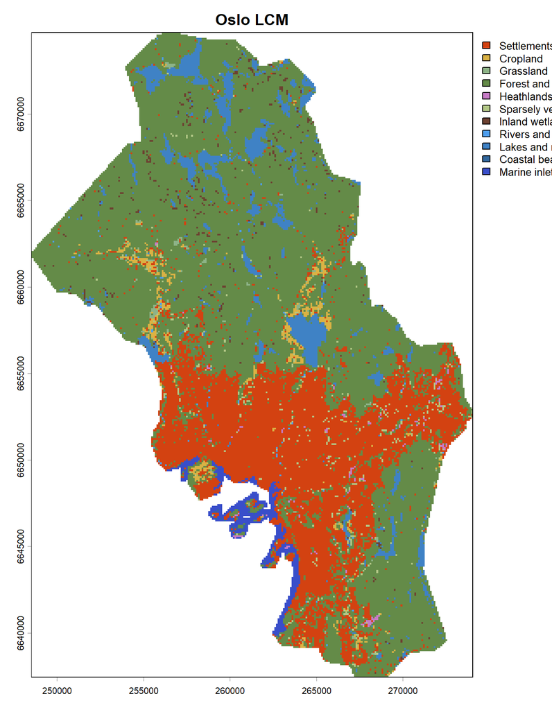

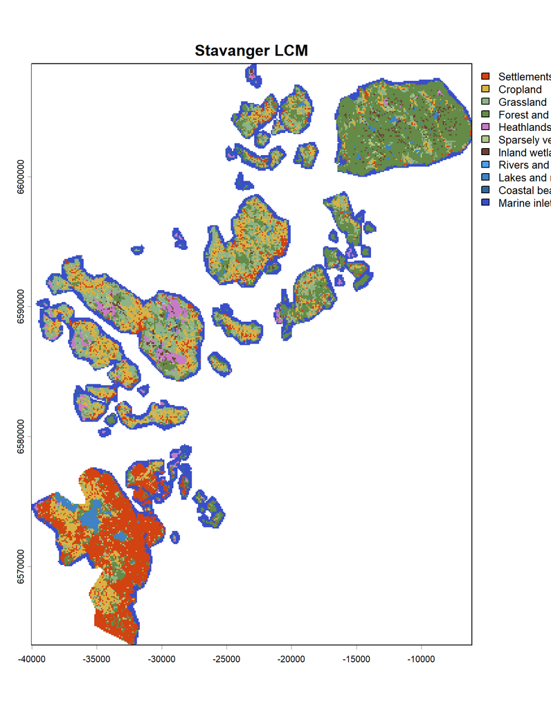

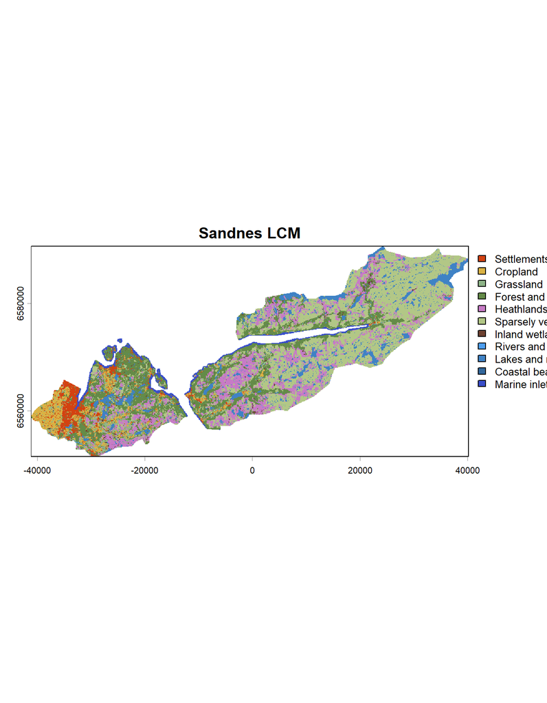

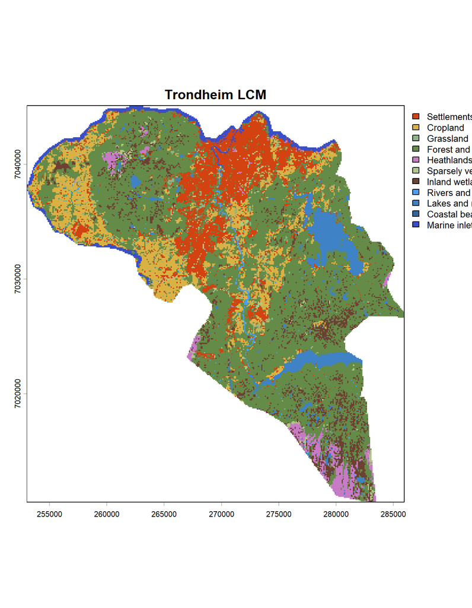

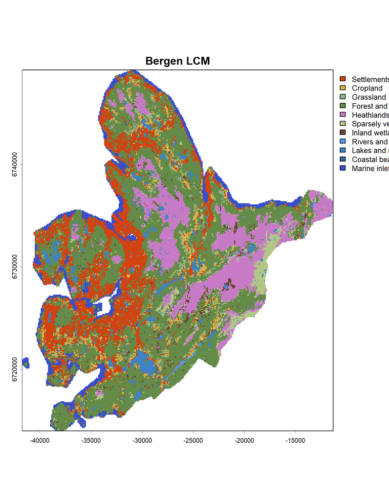

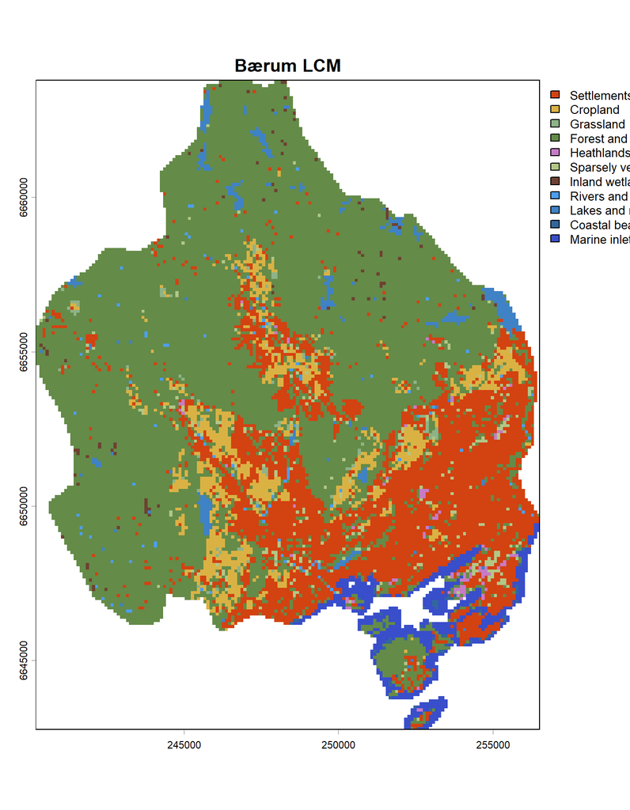

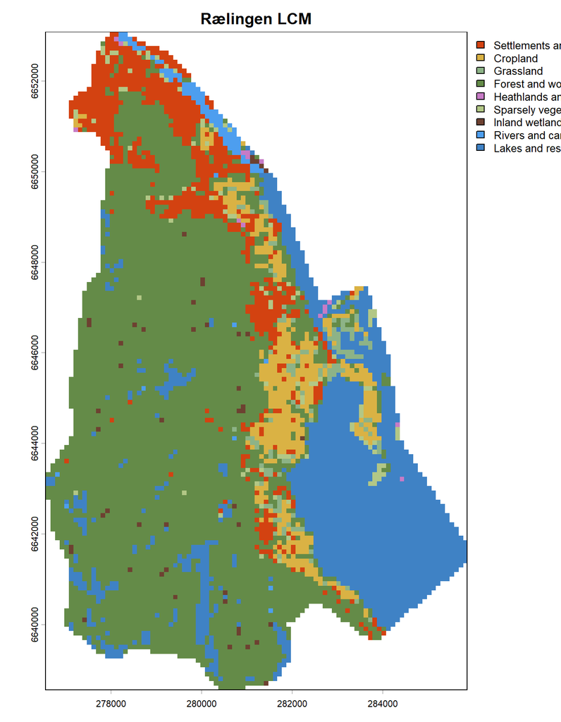

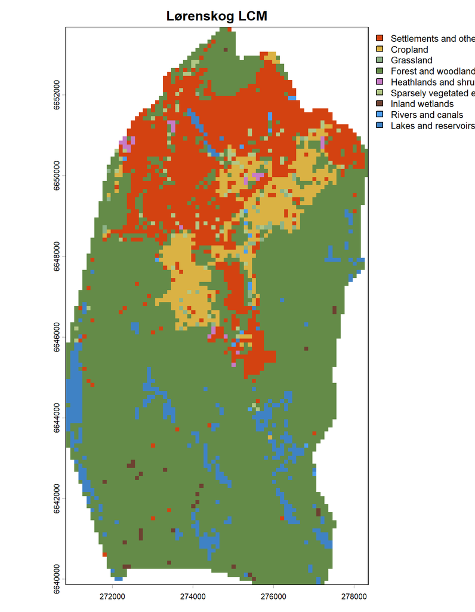

```r
gc()
# read Grunnkartet -------------------------------------------------------------
lcm<-terra::rast(file.path(dfp,"Norway_files","Grunnkart","Grunnkart_OT.tif"))
# project to what we use in this project
lcm <- terra::project(lcm,"EPSG:25833")
# then the recategorisation
lcm_idf<-read.csv(file.path(dfp,"Norway_files","Grunnkart",
                            "Lookup_grunnkart.csv"))
lcm_idf <- rbind(lcm_idf,c(NA,9900,"unclassified","uklassifisert"))
lcm_idf$landcover_id <- as.numeric(lcm_idf$landcover_id)
# make the vector of ecosystem types
estv<-c("Settlements and other artificial areas",
        "Cropland",
        "Grassland",
        "Forest and woodlands",
        "Heathlands and shrub",
        "Sparsely vegetated ecosystems",
        "Inland wetlands",
        "Rivers and canals",
        "Lakes and reservoirs",
        "Marine inlets and transitional waters",
        "Coastal beaches, dunes and wetlands",
        "Marine ecosystems")
# and add it to our lcm_idf
lcm_idf['es_type']<-NA
lcm_idf$es_type[lcm_idf$landcover_id %in% c(100,111,112,121,130,131,132,133,134,135,141,142,152)]<-estv[1] # settlem
lcm_idf$es_type[lcm_idf$landcover_id %in% c(200)]<-estv[2] # cropl
lcm_idf$es_type[lcm_idf$landcover_id %in% c(310,320)]<-estv[3] # grassl
lcm_idf$es_type[lcm_idf$landcover_id %in% c(400,410,420,440)]<-estv[4] # forest
lcm_idf$es_type[lcm_idf$landcover_id %in% c(520)]<-estv[5] # bush
lcm_idf$es_type[lcm_idf$landcover_id %in% c(600,611,623,631)]<-estv[6] # sparse
lcm_idf$es_type[lcm_idf$landcover_id %in% c(720)]<-estv[7] # wetlands
lcm_idf$es_type[lcm_idf$landcover_id %in% c(810)]<-estv[8] # rivers
lcm_idf$es_type[lcm_idf$landcover_id %in% c(910)]<-estv[9] # lakes
lcm_idf$es_type[lcm_idf$landcover_id %in% c(1100)]<-estv[11] # coastal
lcm_idf$es_type[lcm_idf$landcover_id %in% c(1200)]<-estv[10] # marine inlets
lcm_idf$es_type[lcm_idf$landcover_id %in% c(9900)]<-estv[12] # marine ecosystems
# make a numeric identifier also
lcm_idf$es_id <- match(lcm_idf$es_type, unique(estv))
# then add to raster
lev <- levels(lcm)[[1]]
lev$es_id <- lcm_idf$es_id[
  match(lev$Value, lcm_idf$landcover_id)
]
lev$es_type <- lcm_idf$es_type[
  match(lev$Value, lcm_idf$landcover_id)
]
levels(lcm) <- lev
# so here we can set which category we want to plot.
# Can always see which categories we have available by calling cats(lcm)
activeCat(lcm) <- "es_type"
rm(lev)
# # download OSM data
# # A function to download roads data for specific shapes within Norway
# osm_get_streets_for_shp<-function(kshp){
#   # reproject our shape to something that works with degrees
#   kshp_w84 <- project(kshp, "EPSG:4326")
#   # download roads
#   roads <- kshp_w84 %>%
#     sf::st_as_sf() %>%
#     sf::st_bbox() %>%
#     osmdata::opq() %>%
#     osmdata::add_osm_feature(key="highway",value = c("motorway","trunk","primary","secondary")) %>%
#     osmdata_sf()
#   # reproject
#   roads_t <- roads$osm_lines %>%
#     terra::vect() %>%
#     terra::project(kshp)
#   # return result
#   return(roads_t)
# }
# road_shp_list<-list()
# for(i in 1:nrow(cityb_buf)){
#   print(i)
#   road_shp_list[[i]]<- osm_get_streets_for_shp(cityb_buf[i,])
# }

# Make a plot of all cities
# Let's plot the data
for(i in 1:nrow(cityb_buf)){
plot(mask(crop(lcm, cityb_buf[i,]),cityb_buf[i,]),main=paste(cityb_buf$LAU_NAME[i],"LCM"), legend=T)
}
```

Now next we need to identify which of these cities have experienced maximum daily temperatures of at least 25 degrees celsius in the reference year of 2024. For this purpose we first download and import Norwegian meteorological data for 2024 covering the four cities. For now I have eyeballed which weathers stations fit in which city. Given that we observe maximum temperatures of at least 25 degrees celsius in all of them, it does not really matter, the precise selection of weather stations does not really matter. Below we print the weather stations and months in which there where temperatures above 25 deg C.

```r
gc()
# read in meteorogogical data for stations inside the above city LAUs for 2024 -
tempd <- read.csv(file.path(here::here(),"ancillary_data",
                            "NO_2024_citylau_dailymaxtemp.csv"),sep=";")
colnames(tempd)<-c("station_name","station_code","date","maxtemp")
tempd$maxtemp <- sub(",",".",tempd$maxtemp )
tempd$maxtemp <- as.numeric(tempd$maxtemp)
# save all cities with daily temperatures above 25 degrees
stations<-tempd %>% filter(maxtemp >= 25) %>% select(station_name) %>% unique()
# check for months in each city
heatmonths<-list()
for (i in 1:nrow(stations)){
  heatmonths[i]<- tempd %>% filter(maxtemp >= 25) %>% filter(station_name==stations[i,1]) %>% select(date) %>% unique()
}
names(heatmonths)<-stations[,1]
for(i in 1:nrow(stations)){
  print(stations[i,1])
  print(unique(substr(heatmonths[[i]],4,5)))
}
# clean up
rm(stations,tempd,heatmonths)
```

[output not shown]

So this shows that June and July are the months where we have observed daily max temps exceeding 25 degrees in all weather stations within the cities in question in 2024. August and September are months in which some city LAU have observed max temps exceeding 25 degrees. The Eurostat handbook suggests to use an inclusive approach. We therefore pick all available months for the LST data, which we read in next.

```r
# read LST raster file ---------------------------------------------------------
# Here we have data available for June, July, August, September, but we only
# pick June and July, as described above.
lstr_6<-terra::rast(file.path(dfp,"version_2026_7",
                           "inca_input_local_climate_regulation",
                           "Land_Surface_Temperature","2024",
                           "06_LST_2024_eu_masked.tif"))
lstr_7<-terra::rast(file.path(dfp,"version_2026_7",
                           "inca_input_local_climate_regulation",
                           "Land_Surface_Temperature","2024",
                           "07_LST_2024_eu_masked.tif"))
lstr_8<-terra::rast(file.path(dfp,"version_2026_7",
                           "inca_input_local_climate_regulation",
                           "Land_Surface_Temperature","2024",
                           "08_LST_2024_eu_masked.tif"))
lstr_9<-terra::rast(file.path(dfp,"version_2026_7",
                           "inca_input_local_climate_regulation",
                           "Land_Surface_Temperature","2024",
                           "09_LST_2024_eu_masked.tif"))
# rough crop ext
norcrop <- ext(
  3.5e6, 5.5e6, # xmin, xmax
  3.5e6, 5.5e6 # ymin, ymax
)
lstr_6_no <- crop(lstr_6,norcrop)
lstr_7_no <- crop(lstr_7,norcrop)
lstr_8_no <- crop(lstr_8,norcrop)
lstr_9_no <- crop(lstr_9,norcrop)

# reproject
lstr_6_no <- terra::project(lstr_6_no,"EPSG:25833")
lstr_7_no <- terra::project(lstr_7_no,"EPSG:25833")
lstr_8_no <- terra::project(lstr_8_no,"EPSG:25833")
lstr_9_no <- terra::project(lstr_9_no,"EPSG:25833")

# mask to city LAUs
lstr_6_no <- mask(crop(lstr_6_no,cityb_buf),cityb_buf)
lstr_7_no <- mask(crop(lstr_7_no,cityb_buf),cityb_buf)
lstr_8_no <- mask(crop(lstr_8_no,cityb_buf),cityb_buf)
lstr_9_no <- mask(crop(lstr_9_no,cityb_buf),cityb_buf)

## MM comment: The unit of the data is Kelvin. Vito has applied the scaling factor
# that is mentioned here:
# https://www.usgs.gov/landsat-missions/landsat-collection-2-surface-temperature
# You can trace the step in line 131 here
# https://code.europa.eu/inca/gis-plugins/gis-plugins/-/blob/main/src/inca/localclimate/preprocessing/preprocess_LST.js?ref_type=heads

# Move LST data all into one stack
lstr_stack <- c(lstr_6_no,lstr_7_no,lstr_8_no,lstr_9_no)
rm(lstr_6_no,lstr_7_no,lstr_8_no,lstr_9_no,lstr_6,lstr_7,lstr_8,lstr_9)
```

Then plot the LST data, to show that it has gaps. We use the land cover map as background. First for June:

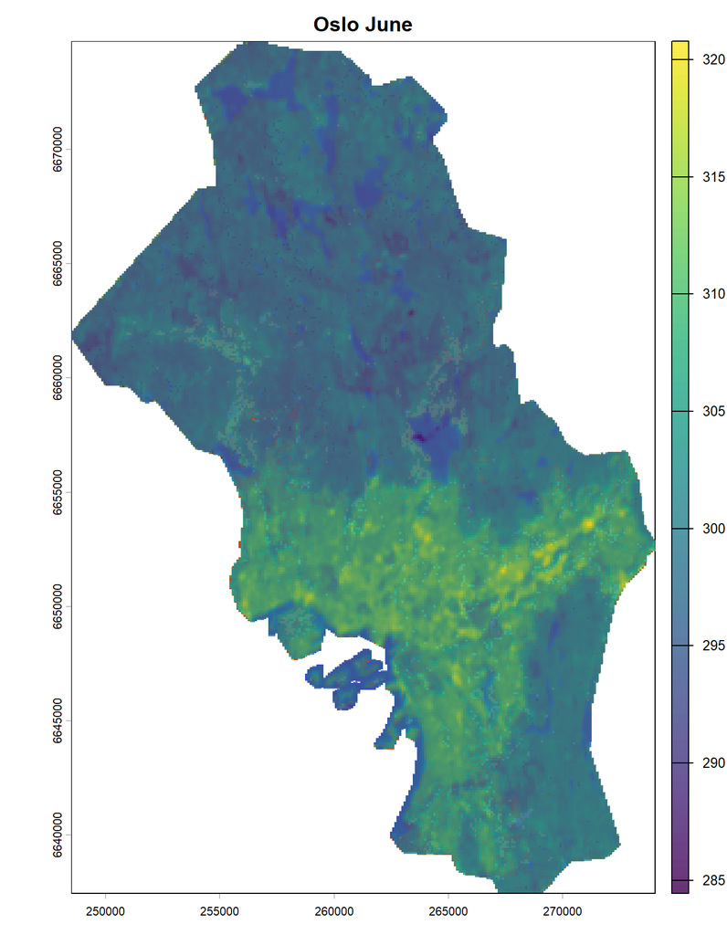

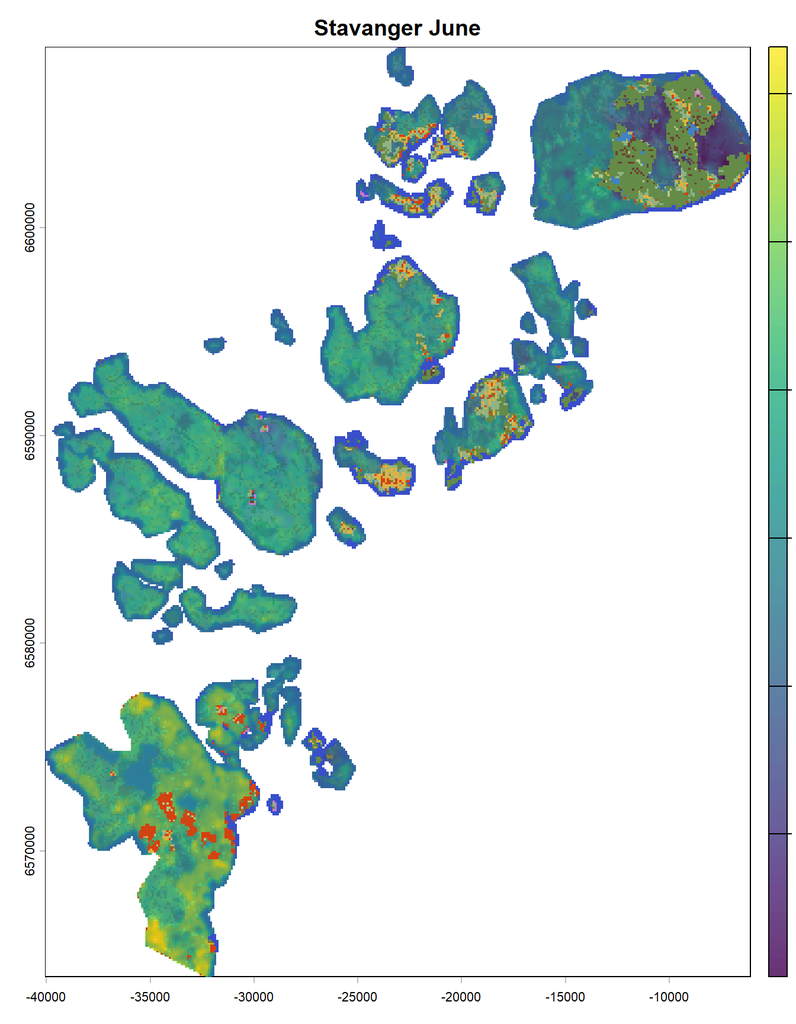

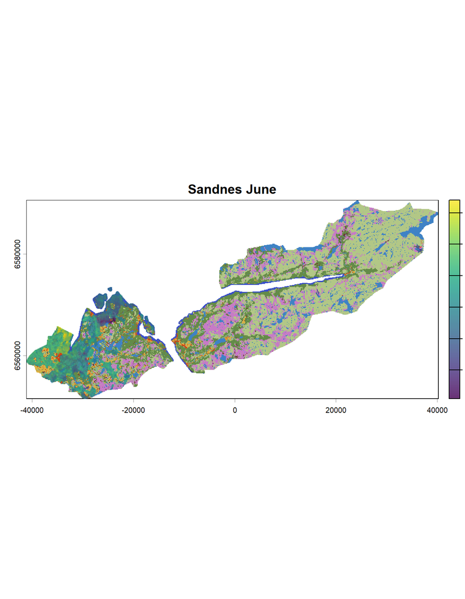

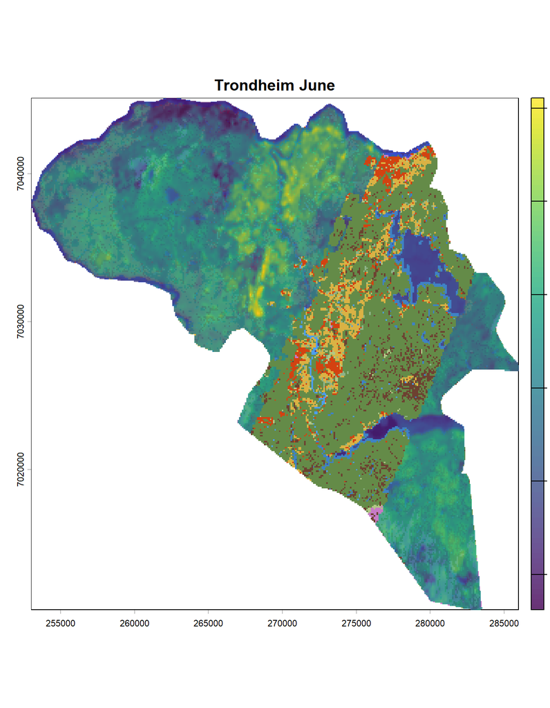

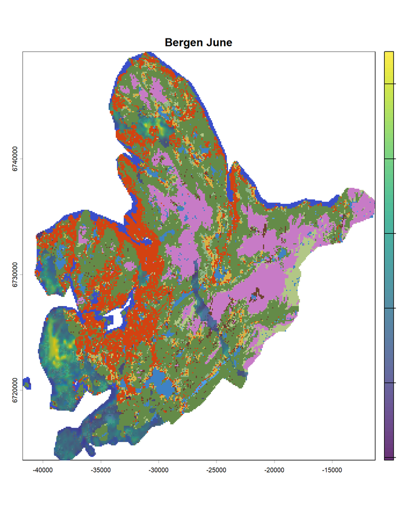

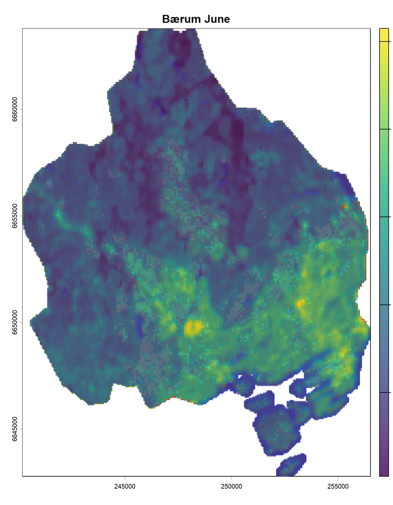

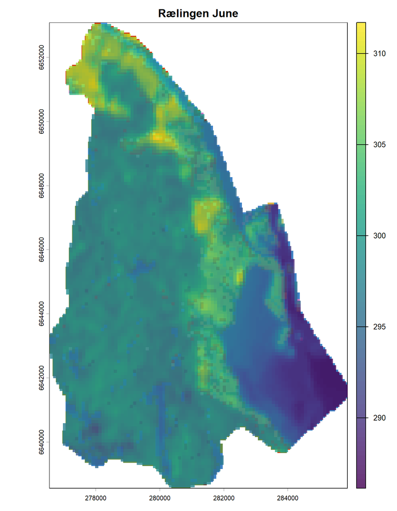

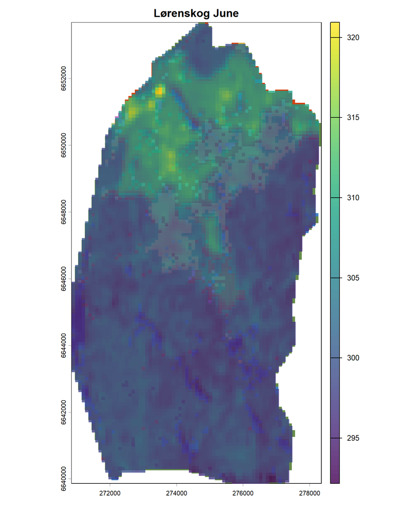

```r
# Let's plot the data
for(i in 1:nrow(cityb_buf)){
plot(mask(crop(lcm, cityb_buf[i,]),cityb_buf[i,]),main=paste(cityb_buf$LAU_NAME[i],"June"), legend=F)
plot(mask(crop(lstr_stack[[1]], cityb_buf[i,]),cityb_buf[i,]),add=T,alpha=0.8)
}
```

You see the largets data gaps for Sandnes and Bergen. Also some gaps for Trondheim and Stavanger. Then look at the maps for July:

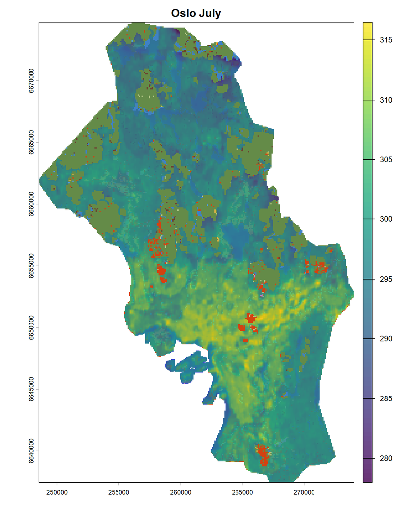

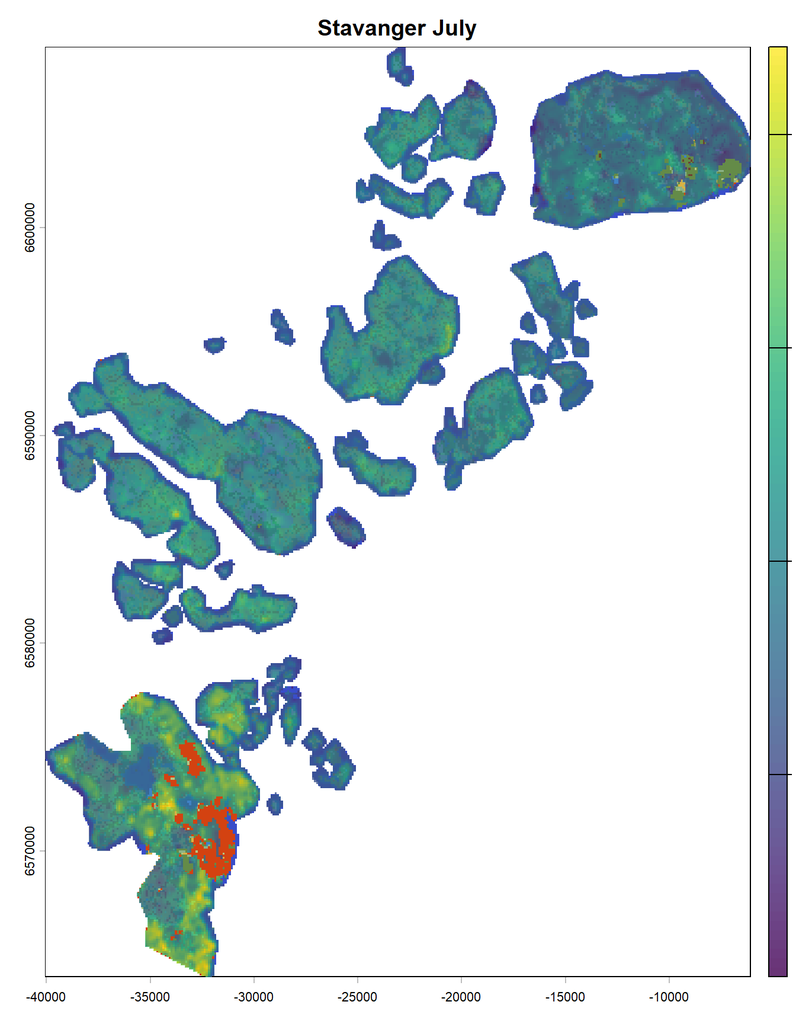

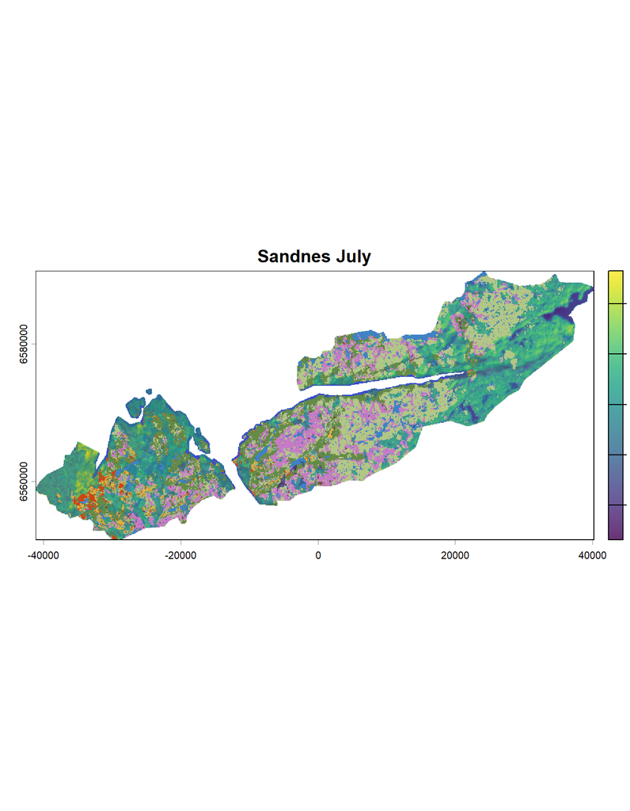

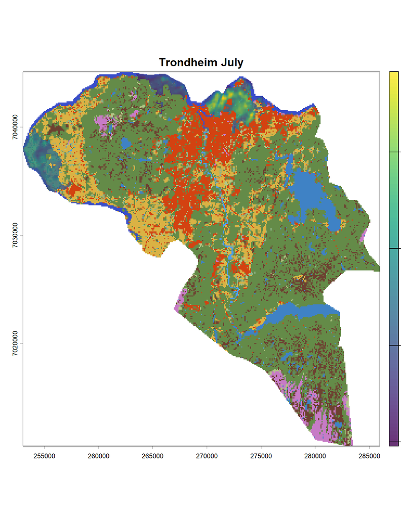

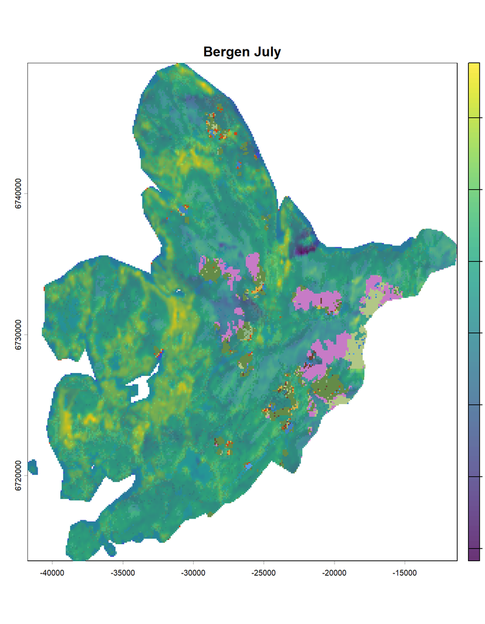

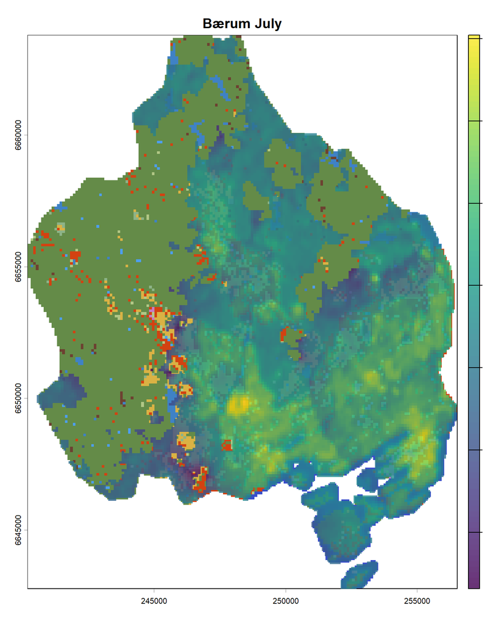

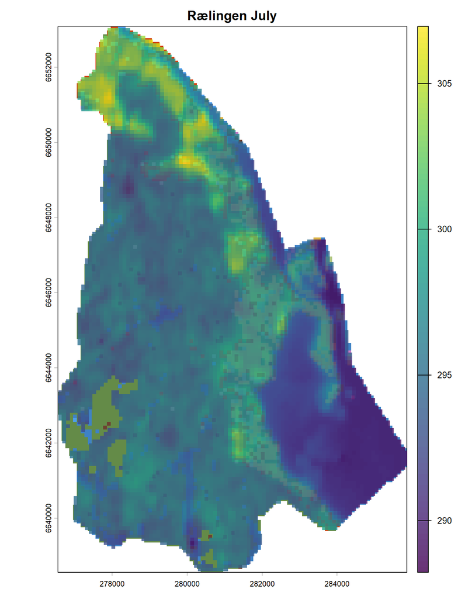

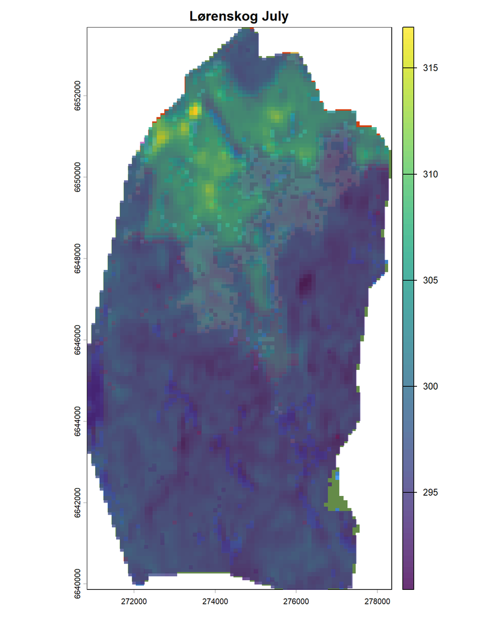

```r
# Let's plot the data
for(i in 1:nrow(cityb_buf)){
plot(mask(crop(lcm, cityb_buf[i,]),cityb_buf[i,]),main=paste(cityb_buf$LAU_NAME[i],"July"), legend=F)
plot(mask(crop(lstr_stack[[2]], cityb_buf[i,]),cityb_buf[i,]),add=T,alpha=0.8)
}
```

Then we read in the other raster files needed. Tree cover density and then evaporation. For evaporation we have the choice between different datasets. One covering July to August, one covering June to August, and a third covering June to September. There is no guidance in the Eurostat handbook on which data to choose. To match the LST data selection, we choose to use June to September.

```r
# read TCD raster file ---------------------------------------------------------
tcdr<-terra::rast(file.path(dfp,"version_2026_7",
                           "inca_input_local_climate_regulation",
                           "Tree_Cover_Density","2023",
                           "TCD_100m_2023_compressed.tif"))
# rough crop
tcdr_no <- crop(tcdr,norcrop)
# reproject
tcdr_no <- terra::project(tcdr_no,"EPSG:25833")
# mask to city lau
tcdr_no <- mask(crop(tcdr_no,cityb_buf),cityb_buf)
# MM I have checked the resulting data and it looks fine. No gaps.

# read EVAP raster file --------------------------------------------------------
evapr<-terra::rast(file.path(dfp,"version_2026_7",
                           "inca_input_local_climate_regulation",
                           "Vegetation_Evapotranspiration","2024",
                           "interc_transp_2024_Jun-Jul-Aug-Sept.tif"))
# rough crop
evapr_no <- crop(evapr,norcrop)
# reproject
evapr_no <- terra::project(evapr_no,"EPSG:25833")
# resample (because the data has a different resolution)
evapr_no <- terra::resample(evapr_no, tcdr_no)
# mask to city lau
evapr_no <- mask(crop(evapr_no,cityb_buf),cityb_buf)
# When plotting the resulting map we see that it is a bit patchy, too. Possibly
# revisit later.
# tidy up
rm(tcdr,evapr)
```

## 3.3 Run regressions

We loop across cities and across available months here. In each city and month we run a regression where grid cells are units of observation. Predicting LST with TCD and EVAP. We store the resulting intercepts for each city and month.

```r
# months to consider
mdr<-c(6,7,8,9)

# our dataframe for results
reg1df<-as.data.frame(matrix(nrow=1,ncol=10))
colnames(reg1df)<-c("month","city","est_intercept","adj_r2","n_used","n_rm","n_rm_p_due_lst_only","n_rm_p_due_tcd_only","n_rm_p_due_evap_only","n_rm_p_due_several")
# function
first_regression_function<-function(cityshp,lst_rfile,tcd_rfile,evap_rfile){
  # Step 1: Crop the data to the right shape, stack it, and turn into df
  estack<-c(mask(crop(lst_rfile, cityshp),cityshp),
            mask(crop(tcd_rfile, cityshp),cityshp),
            mask(crop(evap_rfile, cityshp),cityshp))
  names(estack)<-c("lst","tcd","evap")
  edf<-as.data.frame(estack)
  rm(estack)
  # Step 2: Run regression
  elm <- lm(lst ~ tcd + evap, data = edf)
  # Step 3: Save relevant info
  rv<-vector()
  # estimated intercept of the linear model
  rv[1]<- elm$coefficients[1]
  # adjusted r squared
  rv[2]<- summary(elm)$adj.r.squared
  # observations used
  rv[3]<- nobs(elm)
  # number of observations removed due to missing data
  rv[4]<- nrow(edf) - nobs(elm)
  # proportion of removed ovservations due to missing lst data only
  rv[5]<- round(sum(is.na(edf$lst) &
                     !is.na(edf$evap) &
                     !is.na(edf$tcd)) / rv[4],digits=2)
  # proportion of removed ovservations due to missing tcd data only
  rv[6]<- round(sum(is.na(edf$tcd) &
                      !is.na(edf$evap) &
                      !is.na(edf$lst)) / rv[4],digits=2)
  # proportion of removed ovservations due to missing evap data only
  rv[7]<- round(sum(is.na(edf$evap) &
                      !is.na(edf$lst) &
                      !is.na(edf$tcd)) / rv[4],digits=2)
  # proportion of removed observations due to several missing variables
  rv[8]<-round(sum(rowSums(is.na(edf[, c("lst", "evap", "tcd")])) >= 2)/rv[4],digits=2)
  # clean up and return result
  rm(edf,elm)
  return(rv)
}

## then loop across months and cities
rl<-list()
for(j in 1:length(mdr)){
  rl[[j]]<-reg1df
  for(i in 1:nrow(cityb_buf)){
    rl[[j]][i,1]<-mdr[j]
    rl[[j]][i,2]<-as.data.frame(cityb_buf[i,])$LAU_NAME
    rl[[j]][i,3:10]<-first_regression_function(cityshp = cityb_buf[i,],
                                lst_rfile = lstr_stack[[j]],
                                tcd_rfile = tcdr_no,
                                evap_rfile = evapr_no)
  }
}
firstdf<-do.call("rbind",rl)
rm(reg1df,rl)

# save intercept in raster stack
# one raster per month
intercept_rasters <- vector("list", length(mdr))
# loop across months
for (j in seq_along(mdr)) {
    # subset results for current month
  month_df <- subset(firstdf, month == mdr[j])
    # copy polygons
  city_month <- cityb_buf
    # attach intercepts and convert to degree celsius
  city_month$est_intercept <- month_df$est_intercept[
    match(city_month$LAU_NAME, month_df$city)
  ] - 273.15
    # rasterize
  intercept_rasters[[j]] <- terra::rasterize(
    city_month,
    lstr_stack[[1]], # as a template
    field = "est_intercept"
  )
  rm(city_month,month_df)
}
# create SpatRaster stack
intercept_stack <- rast(intercept_rasters)
names(intercept_stack) <- paste0("intercept_", mdr)
# tidy up
rm(intercept_rasters)
```

Print the table, with rounded values.

```r
# print result table
kable(firstdf %>% mutate(across(where(is.numeric), ~ round(.x, 2))))
```

| month | city | est_intercept | adj_r2 | n_used | n_rm | n_rm_p_due_lst_only | n_rm_p_due_tcd_only | n_rm_p_due_evap_only | n_rm_p_due_several |
| --- | --- | --- | --- | --- | --- | --- | --- | --- | --- |
| 6 | Oslo | 306.33 | 0.56 | 46551 | 1472 | 0.01 | 0 | 0.99 | 0.01 |
| 6 | Stavanger | 296.90 | 0.42 | 19561 | 14663 | 0.27 | 0 | 0.54 | 0.18 |
| 6 | Sandnes | 294.65 | 0.33 | 13191 | 97243 | 0.93 | 0 | 0.01 | 0.06 |
| 6 | Trondheim | 299.97 | 0.22 | 34065 | 21096 | 0.91 | 0 | 0.09 | 0.01 |
| 6 | Bergen | 299.27 | 0.46 | 4666 | 45131 | 0.89 | 0 | 0.04 | 0.07 |
| 6 | Bærum | 305.76 | 0.60 | 20243 | 694 | 0.01 | 0 | 0.99 | 0.00 |
| 6 | Rælingen | 298.53 | 0.22 | 6892 | 1059 | 0.00 | 0 | 1.00 | 0.00 |
| 6 | Lørenskog | 309.43 | 0.64 | 7713 | 0 | NaN | NaN | NaN | NaN |
| 7 | Oslo | 304.52 | 0.50 | 36885 | 11138 | 0.87 | 0 | 0.13 | 0.00 |
| 7 | Stavanger | 298.32 | 0.34 | 22548 | 11690 | 0.09 | 0 | 0.89 | 0.02 |
| 7 | Sandnes | 296.11 | 0.08 | 42637 | 67806 | 0.90 | 0 | 0.05 | 0.06 |
| 7 | Trondheim | 295.93 | 0.50 | 2270 | 52887 | 0.96 | 0 | 0.01 | 0.03 |
| 7 | Bergen | 298.44 | 0.28 | 40636 | 9181 | 0.48 | 0 | 0.52 | 0.00 |
| 7 | Bærum | 305.60 | 0.47 | 12158 | 8779 | 0.92 | 0 | 0.08 | 0.00 |
| 7 | Rælingen | 296.19 | 0.20 | 6683 | 1268 | 0.16 | 0 | 0.84 | 0.00 |
| 7 | Lørenskog | 306.27 | 0.64 | 7679 | 34 | 1.00 | 0 | 0.00 | 0.00 |
| 8 | Oslo | 300.52 | 0.57 | 46552 | 1471 | 0.00 | 0 | 0.99 | 0.00 |
| 8 | Stavanger | 297.96 | 0.55 | 19280 | 14942 | 0.29 | 0 | 0.52 | 0.19 |
| 8 | Sandnes | 298.48 | 0.28 | 72079 | 38377 | 0.82 | 0 | 0.13 | 0.05 |
| 8 | Trondheim | 292.49 | 0.27 | 29110 | 26050 | 0.92 | 0 | 0.05 | 0.02 |
| 8 | Bergen | 292.00 | 0.52 | 306 | 49482 | 0.90 | 0 | 0.00 | 0.09 |
| 8 | Bærum | 300.02 | 0.62 | 20245 | 692 | 0.01 | 0 | 0.99 | 0.00 |
| 8 | Rælingen | 294.60 | 0.25 | 6892 | 1059 | 0.00 | 0 | 1.00 | 0.00 |
| 8 | Lørenskog | 302.19 | 0.67 | 7713 | 0 | NaN | NaN | NaN | NaN |
| 9 | Oslo | 292.03 | 0.31 | 46552 | 1471 | 0.00 | 0 | 0.99 | 0.00 |
| 9 | Stavanger | 296.23 | 0.35 | 18974 | 15257 | 0.30 | 0 | 0.54 | 0.16 |
| 9 | Sandnes | 293.72 | 0.05 | 99568 | 10889 | 0.35 | 0 | 0.62 | 0.03 |
| 9 | Trondheim | 292.45 | 0.07 | 33906 | 21255 | 0.91 | 0 | 0.09 | 0.01 |
| 9 | Bergen | 290.97 | 0.16 | 44474 | 5343 | 0.11 | 0 | 0.89 | 0.01 |
| 9 | Bærum | 290.00 | 0.26 | 20245 | 692 | 0.01 | 0 | 0.99 | 0.00 |
| 9 | Rælingen | 288.75 | 0.20 | 6892 | 1059 | 0.00 | 0 | 1.00 | 0.00 |
| 9 | Lørenskog | 292.98 | 0.38 | 7713 | 0 | NaN | NaN | NaN | NaN |

# 4. Estimate a Model of Air Temperature

## 4.1 Overview

In this second step we use weather station data to estimate a linear model of maximum air temperature predicted by local surface temperature and latitude. Here is the unit of observation is weather stations. We save the estimated coefficients.

## 4.2 Import data

Read in a single dataframe containing weather station data. This is the training data from the US.

```r
# read in weather station data
wstd<-read.csv(file.path(dfp,"version_2026_7",
                           "inca_input_local_climate_regulation",
                           "Weather_station_data",
                           "StationNeighborhood2016.csv"))
```

## 4.3 Run regression

A single regression to estimate a linear model. Predicting maximum air temperature with local surface temperature and latitude. The model we estimate is:
$$T^{air} = \beta_{2} LST +
\gamma_{2}LAT$$

```r
# So here we now estimate the model and store the coefficients and adjusted r squared
wlm <- lm(TempMax ~ st + Ycoor, data = wstd)
beta2h <- wlm$coefficients['st']
gamma2h <- wlm$coefficients['Ycoor']
wlm_adjr2<-summary(wlm)$adj.r.squared
# tidy up
rm(wstd)
```

Here are model outputs:

```r
summary(wlm)
```

```
##
## Call:
## lm(formula = TempMax ~ st + Ycoor, data = wstd)
##
## Residuals:
##     Min      1Q  Median      3Q     Max
## -14.325  -1.181   1.004   2.027  12.798
##
## Coefficients:
##              Estimate Std. Error t value Pr(>|t|)
## (Intercept) 40.633197   0.440522   92.24   <2e-16 ***
## st           0.256994   0.006482   39.65   <2e-16 ***
## Ycoor       -0.524943   0.008085  -64.93   <2e-16 ***
## ---
## Signif. codes:  0 '***' 0.001 '**' 0.01 '*' 0.05 '.' 0.1 ' ' 1
##
## Residual standard error: 3.251 on 6507 degrees of freedom
## Multiple R-squared:  0.5214, Adjusted R-squared:  0.5213
## F-statistic:  3545 on 2 and 6507 DF,  p-value: < 2.2e-16
```

```r
rm(wlm)
```

# 5. Simulate Air Temperature for the City Grids

## 5.1 Overview

Here we now apply the estimated coefficients from the previous two steps to generate simulated gridded data. We do this for each city. Given that we have observed LST data at grid level, we compute for each grid cell $i$ the expected air temperature
$$T^{air}_{j,i} =
\widehat{\beta_{2}} LST_{j,i} + \widehat{\gamma_{2}} latitude_{j,i}$$
.

Then we compute for each grid cell $i$ the expected air temperature in a no-vegetation scenario, i.e. where $LST_{j,i} = \widehat{\alpha_{1,j}}$. So
$$T^{air,0}_{ji} = \widehat{\beta_{2}} \widehat{\alpha_{1,j}} +
\widehat{\gamma_{2}} latitude_{j,i}$$
.

The cooling effect is then retrieved for each grid cell $i$ in city $j$ as
$$cooling_{j,i} = T^{air}_{j,i} - T^{air,0}_{j,i}$$
.

## 5.2 Create cooling rasters

Make a loop where we compute the cooling rasters for each city in each month.

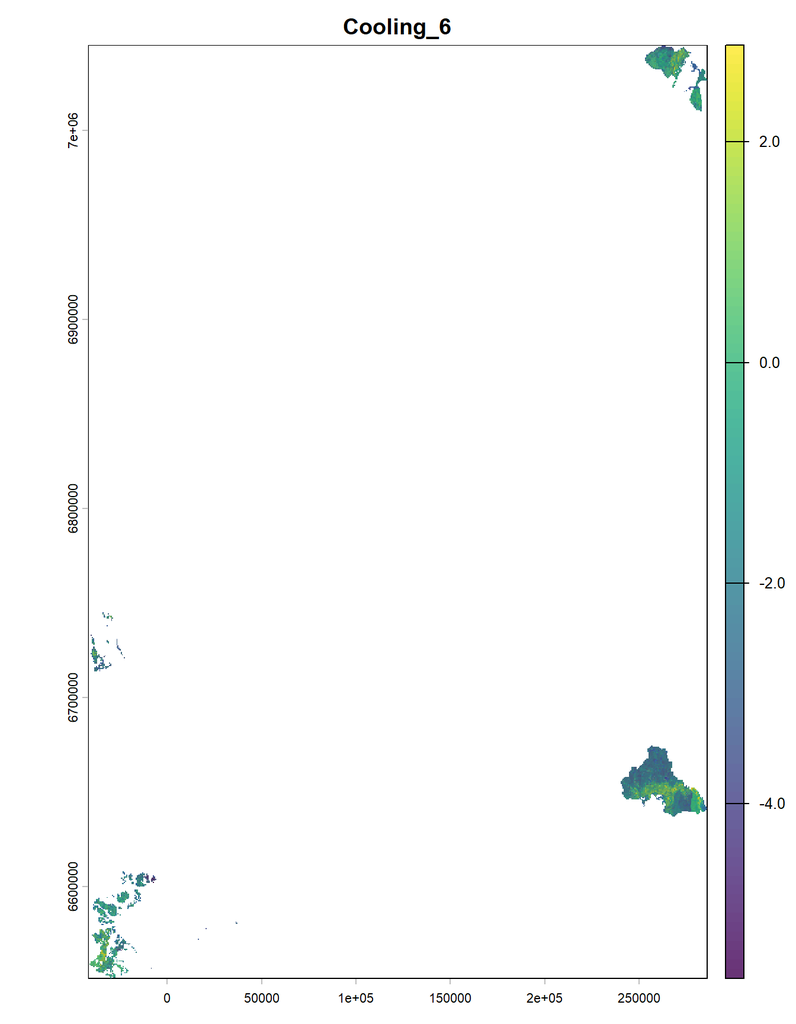

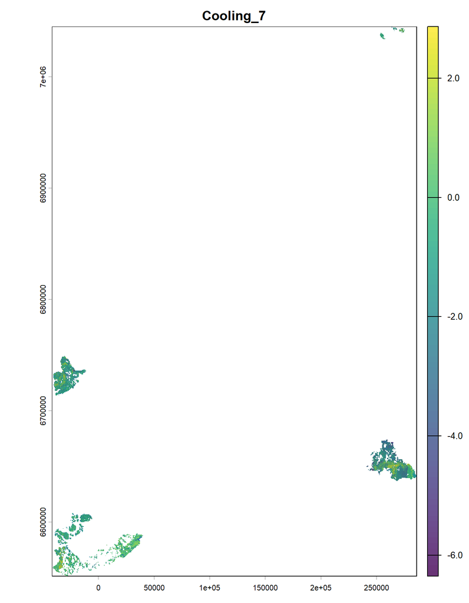

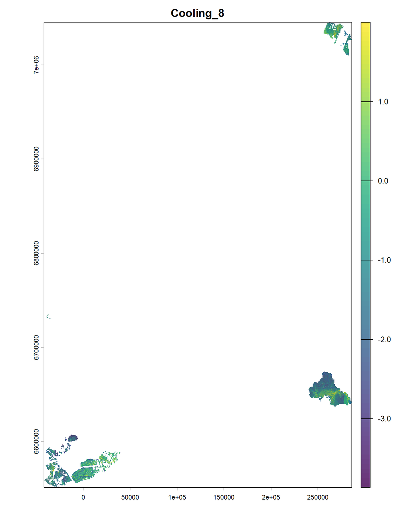

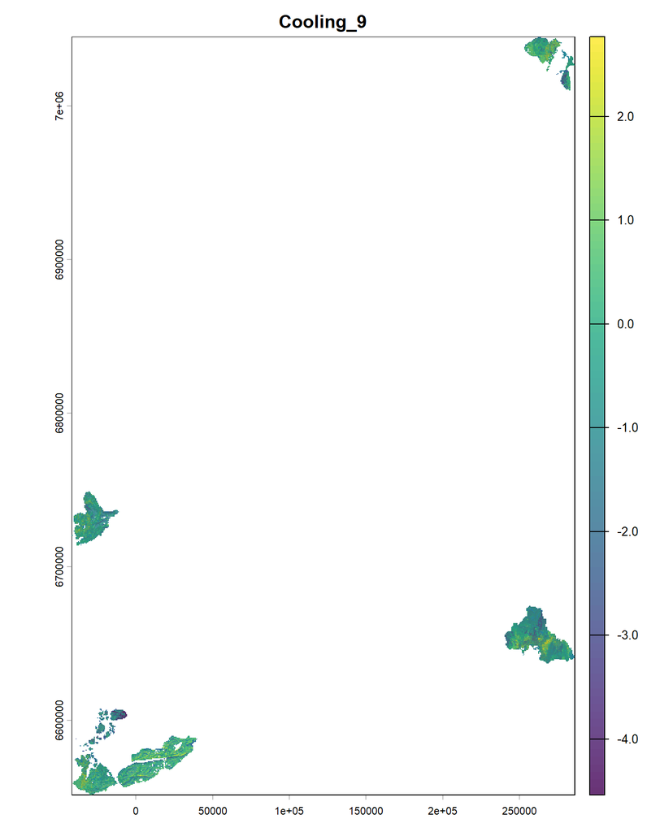

```r
# first we create a latitude raster
# Project raster to geographic coordinates
tmp_ll <- project(lstr_stack[[1]], "EPSG:4326")
# Create latitude raster
lat_ll <- init(tmp_ll, "y")
# Back to the original grid
lat_r <- project(lat_ll, lstr_stack[[1]])
rm(tmp_ll,lat_ll)
# then compute the cooling rasters in a loop across months
# the loop
cooling_rasters <- vector("list", length(mdr))
# loop across months
for (j in seq_along(mdr)) {
  # modelled temp
  tairr <- (lstr_stack[[j]] - 273.15)*beta2h #+ lat_r*gamma2h
  # modelled temp no trees
  tairnr <- intercept_stack[[j]]*beta2h #+ lat_r*gamma2h
  # cooling
  coolingr <- tairr - tairnr
  # save
  cooling_rasters[[j]] <- coolingr
  writeRaster(coolingr,file.path(rfp,paste0("cooling_",mdr[j],".tif")),overwrite=T)
  # tidy up
  rm(tairr,tairnr,coolingr)
}
# create SpatRaster stack
cooling_stack <- rast(cooling_rasters)
names(cooling_stack) <- paste0("Cooling_", mdr)
# now for plots and aggregations need to align extents perfectly
lcm <- resample(
  lcm,
  cooling_stack[[j]],
  method = "near"
)
# need to recode lcm raster
rcl <- as.matrix(cats(lcm)[[1]][, c("Value", "es_id")])
lcm2 <- classify(lcm, rcl)
# then plot
for(j in 1:4){
  plot(mask(crop(lcm, cooling_stack[[j]]),cooling_stack[[j]]),
       main = names(cooling_stack)[j],
       legend = FALSE)
  plot(
    cooling_stack[[j]],
    add = TRUE,alpha = 0.8)
}
```

```r
# tidy up
rm(lat_r,cooling_rasters)
```

# 6. Summarise results

Here we now summarise the data across grid cells (and time). The final outputs are SUT tables. We compute average cooling by ecosystem type and area, and weighted average cooling across all ecosystem types by area.

## 6.1 Supply tables for City LAUs in Norway

```r
### Make a function and then run for each month
cooling_by_city<-function(j){
  df_sut<-as.data.frame(matrix(ncol=14,nrow=nrow(cityb_buf)))
  colnames(df_sut)<-c("LAU",estv,"w_avg_cool")
  # now loop across LAU
  for(i in 1:nrow(cityb_buf)){
  # the LAU name
  df_sut$LAU[i]<-as.data.frame(cityb_buf[i,])$LAU_NAME
  # compute cooling averages
  # using terra zonal
  z <- terra::zonal(mask(crop(cooling_stack[[j]], cityb_buf[i,]),cityb_buf[i,]), # values
                    mask(crop(lcm2, cityb_buf[i,]),cityb_buf[i,]),# categories
                    fun="mean",
                    na.rm=T)
  # set column names
  colnames(z) <- c("es_id","cooling")
  # add ecosystem names
  z$es_name <- lcm_idf$es_type[
    match(z$es_id, lcm_idf$es_id)]
  # here is the weighted cooling across all ecosystems
  dfp<-freq(mask(crop(lcm2, cityb_buf[i,]),cityb_buf[i,]))
  dfp['es_weight']<-dfp$count / freq(mask(crop(lcm2, cityb_buf[i,]),cityb_buf[i,])) %>% select(count) %>% sum()
  z <- z %>% left_join(dfp,by=join_by("es_id" == "value"))
  z['weighted_average_cooling']<-z$cooling*z$es_weight
  rm(dfp)
  # paste result into our table, loop again, just to ensure we keep empty values where ecosystems do not exist
  for(k in 1:length(estv)){
    df_sut[i,k+1]<- {
      x <- z %>% filter(es_name==estv[k]) %>% pull(cooling)
      if(length(x) == 0) NA else x
    }
    rm(x)
  }
  # finally the weighted average for the LAU as a whole
  df_sut$w_avg_cool[i]<-sum(z$weighted_average_cooling)
  rm(z)
  }
#return result
return(df_sut)
}

# then run
city_st_6 <- cooling_by_city(j=1)
city_st_7 <- cooling_by_city(j=2)
city_st_8 <- cooling_by_city(j=3)
city_st_9 <- cooling_by_city(j=4)
```

Here are the results for June (rounded)

```r
kable(city_st_6 %>% mutate(across(where(is.numeric), ~ round(.x, 2))))
```

| LAU | Settlements and other artificial areas | Cropland | Grassland | Forest and woodlands | Heathlands and shrub | Sparsely vegetated ecosystems | Inland wetlands | Rivers and canals | Lakes and reservoirs | Marine inlets and transitional waters | Coastal beaches, dunes and wetlands | Marine ecosystems | w_avg_cool |
| --- | --- | --- | --- | --- | --- | --- | --- | --- | --- | --- | --- | --- | --- |
| Oslo | -0.11 | -1.94 | -2.11 | -2.54 | -0.70 | -0.80 | -2.56 | -1.50 | -3.15 | -2.24 | -2.20 | NA | -1.90 |
| Stavanger | -0.14 | -1.05 | -1.35 | -2.18 | -1.38 | -0.96 | -1.99 | -2.11 | -1.98 | -2.28 | -1.81 | NA | -1.55 |
| Sandnes | -0.15 | -0.58 | -0.86 | -1.68 | -0.98 | -0.90 | -1.33 | -1.08 | -1.80 | -1.98 | -1.46 | NA | -1.14 |
| Trondheim | -0.06 | -1.09 | -1.17 | -1.36 | -0.51 | -0.55 | -0.72 | -1.35 | -2.88 | -2.67 | -1.74 | NA | -1.18 |
| Bergen | -1.01 | -1.85 | -1.87 | -2.56 | -2.64 | -1.80 | -2.48 | -1.70 | -2.67 | -3.01 | -2.56 | NA | -2.23 |
| Bærum | -0.46 | -1.57 | -1.82 | -2.49 | -0.88 | -0.79 | -2.51 | -1.56 | -2.78 | -2.18 | -1.69 | NA | -1.91 |
| Rælingen | 1.17 | 0.52 | 0.18 | -0.42 | -0.09 | 0.61 | -0.30 | 0.67 | -1.61 | NA | NA | NA | -0.42 |
| Lørenskog | -0.69 | -2.12 | -2.27 | -2.82 | -1.25 | -1.24 | -2.79 | -1.80 | -3.24 | NA | NA | NA | -2.36 |

Here are the results for July (rounded to two digits)

```r
kable(city_st_7 %>% mutate(across(where(is.numeric), ~ round(.x, 2))))
```

| LAU | Settlements and other artificial areas | Cropland | Grassland | Forest and woodlands | Heathlands and shrub | Sparsely vegetated ecosystems | Inland wetlands | Rivers and canals | Lakes and reservoirs | Marine inlets and transitional waters | Coastal beaches, dunes and wetlands | Marine ecosystems | w_avg_cool |
| --- | --- | --- | --- | --- | --- | --- | --- | --- | --- | --- | --- | --- | --- |
| Oslo | -0.12 | -1.73 | -1.80 | -2.41 | -0.73 | -0.70 | -2.70 | -1.23 | -3.02 | -2.02 | -1.82 | NA | -1.80 |
| Stavanger | 0.02 | -0.71 | -0.79 | -1.21 | -0.80 | -0.47 | -1.10 | -1.24 | -1.37 | -1.57 | -1.20 | NA | -0.95 |
| Sandnes | 0.61 | -0.32 | -0.26 | -0.53 | -0.15 | 0.10 | -0.24 | -0.40 | -1.29 | -1.05 | -0.72 | NA | -0.24 |
| Trondheim | -0.06 | -0.93 | -1.27 | -1.44 | -0.87 | -0.46 | -1.11 | -0.98 | -1.88 | -1.31 | -1.37 | NA | -1.15 |
| Bergen | -0.24 | -1.03 | -1.32 | -1.44 | -1.26 | -1.14 | -1.30 | -1.08 | -1.38 | -1.52 | -1.07 | NA | -1.15 |
| Bærum | -0.88 | -2.44 | -2.17 | -2.48 | -1.04 | -1.05 | -2.44 | -1.33 | -2.38 | -2.21 | -1.92 | NA | -2.06 |
| Rælingen | 0.84 | 0.08 | -0.06 | -0.55 | -0.18 | 0.37 | -0.49 | 0.46 | -1.29 | NA | NA | NA | -0.50 |
| Lørenskog | -0.70 | -2.09 | -2.14 | -2.74 | -1.14 | -1.20 | -2.69 | -1.77 | -3.04 | NA | NA | NA | -2.30 |